# Advanced Analytics Assignment

Karthick

26 March 2018

### 1.Data Analysis

##### Adding the data to the Environment

```r
df = read.csv ("C:\\Users\\Lenovo\\Desktop\\public.csv",header = TRUE)
head(df)
```

```
##   DOB NKID DEP PHON  SINC AES DAINC RES DHVAL DMORT DOUTM DOUTL DOUTHP
## 1  19    4   0    1     0   R     0   O 14464     4     0     0      0
## 2  41    2   0    1     0   P 36000   O     0     0   280   664      0
## 3  66    0   0    1     0   N 30000   N     0     0     0     0      0
## 4  51    2   0    1     0   P   464   O 24928  8464   584   320      0
## 5  65    0   0    1     0   P 15000   P     0     0     0     0      0
## 6  42    2   0    1 10500   E 48000   O 43392 46464  1120     0      0
##   DOUTCC BAD
## 1      0   0
## 2     80   0
## 3      0   0
## 4     60   0
## 5      0   0
## 6      0   0
```

##### Structure of the dataset:

```r
str(df)
```

```
## 'data.frame':    1225 obs. of  15 variables:
##  $ DOB   : num  19 41 66 51 65 42 59 43 52 65 ...
##  $ NKID  : num  4 2 0 2 0 2 0 1 0 0 ...
##  $ DEP   : num  0 0 0 0 0 0 0 0 0 0 ...
##  $ PHON  : int  1 1 1 1 1 1 1 1 1 1 ...
##  $ SINC  : num  0 0 0 0 0 10500 6500 13500 0 0 ...
##  $ AES   : Factor w/ 11 levels "B","E","M","N",..: 6 5 4 5 5 2 1 2 2 5 ...
##  $ DAINC : num  0 36000 30000 464 15000 48000 30000 9000 22500 19500 ...
##  $ RES   : Factor w/ 5 levels "F","N","O","P",..: 3 3 2 3 4 3 3 3 4 3 ...
##  $ DHVAL : num  14464 0 0 24928 0 ...
##  $ DMORT : num  4 0 0 8464 0 ...
##  $ DOUTM : num  0 280 0 584 0 1120 520 0 0 540 ...
##  $ DOUTL : num  0 664 0 320 0 0 0 200 200 0 ...
##  $ DOUTHP: num  0 0 0 0 0 0 96 0 0 0 ...
##  $ DOUTCC: num  0 80 0 60 0 0 0 0 80 0 ...
##  $ BAD   : num  0 0 0 0 0 0 0 0 0 0 ...
```

##### Checking for NA Value

No NA values were found

```r
na_count <-sapply(df, function(y) sum(length(which(is.na(y)))))
na_count
```

```
##    DOB   NKID    DEP   PHON   SINC    AES  DAINC    RES  DHVAL  DMORT
##      0      0      0      0      0      0      0      0      0      0
##  DOUTM  DOUTL DOUTHP DOUTCC    BAD
##      0      0      0      0      0
```

##### Basic Tests for Understanding Variable behaviour and relation with the response

1. For Qualitative Variables

Test the Hypothesis whether there is a difference in mean of the qualitative variable for good vs bad credit score at 0.05 significance level

2. For Categorical Variables

Test the Hypothesis whether the credit score is independent of their levels of different categorical variables at .05 significance level.

##### User Defined Functions:

```r
boxPlotTest <- function(x,y){
  boxplot(x~y)
  pvalue <-t.test(x[y == 0], x[y == 1])$p.value
  print("The p-value for the t-test is ")
  print(pvalue)
}

chiTablePlot <- function(x,y){
  tbl = table(x, y)
  print(tbl)
  chisq.test(tbl)
}
```

Sample Comparison of Quantitative variable : DOUTM

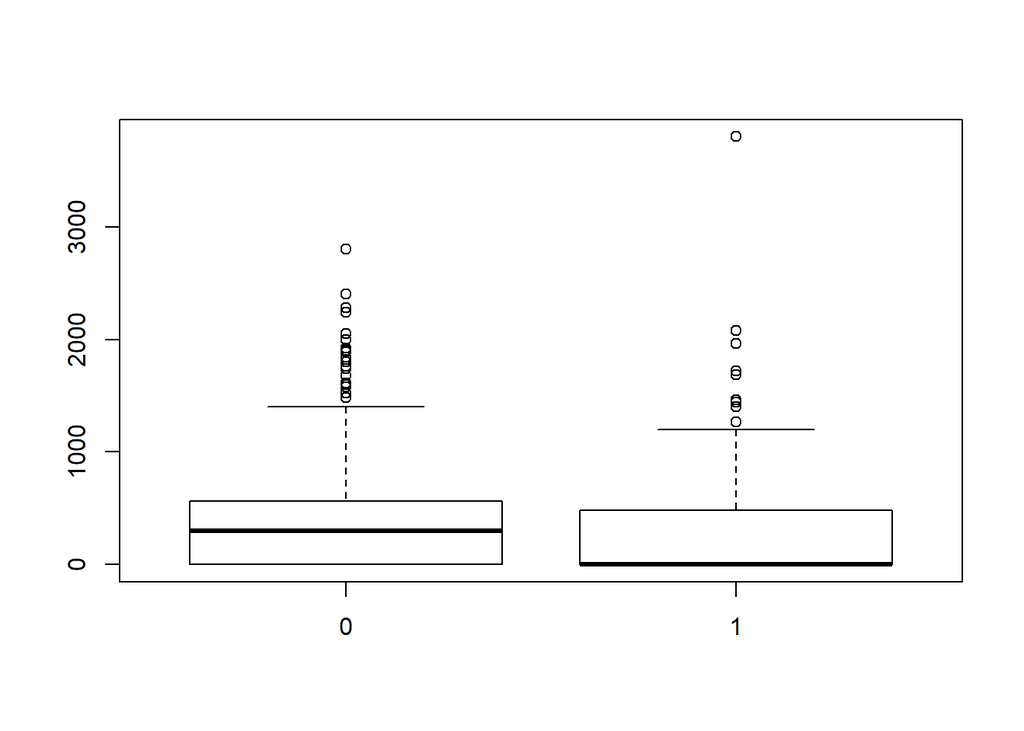

```
## [1] "The p-value for the t-test is "
## [1] 0.02014276
```

```r
boxPlotTest(df$DOUTM,df$BAD)
```

Sample comparison for the Categorical value : NKID

```r
chiTablePlot(df$NKID,df$BAD)
```

```
##    y
## x     0   1
##   0 596 224
##   1 110  37
##   2 137  45
##   3  39  15
##   4  17   2
##   5   3   0
```

```
##
##  Pearson's Chi-squared test
##
## data:  tbl
## X-squared = 4.3276, df = 5, p-value = 0.5033
```

##### Table having significance Value

[output not shown]

The variables with p-value < 0.05 are expected to have some effect on the credit score:

DOB (Age)

Income of individual and spouse

Debts

AES

RES

##### Some more visualisation to understand the correlations

The Value of the home (DHVAL) and Mortgage (DMORT) seem to have positive correlation

For Good credit holders the Individual and Spouse income seems to be not correlated but for BAD credit holders the individual income decreases with Spouse Income.

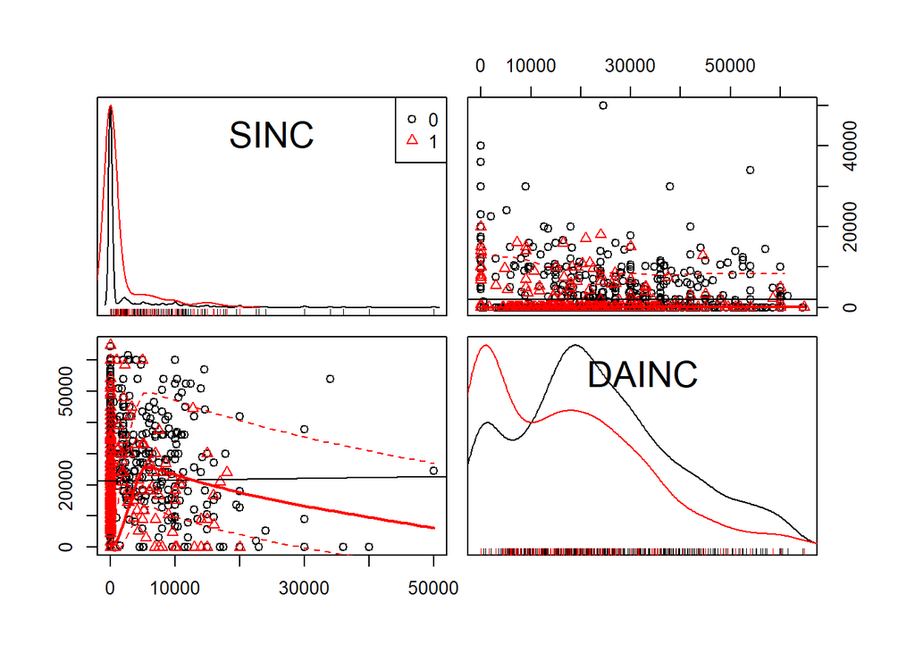

```r
library(car)
scatterplot.matrix(~SINC+DAINC|BAD, data = df)
```

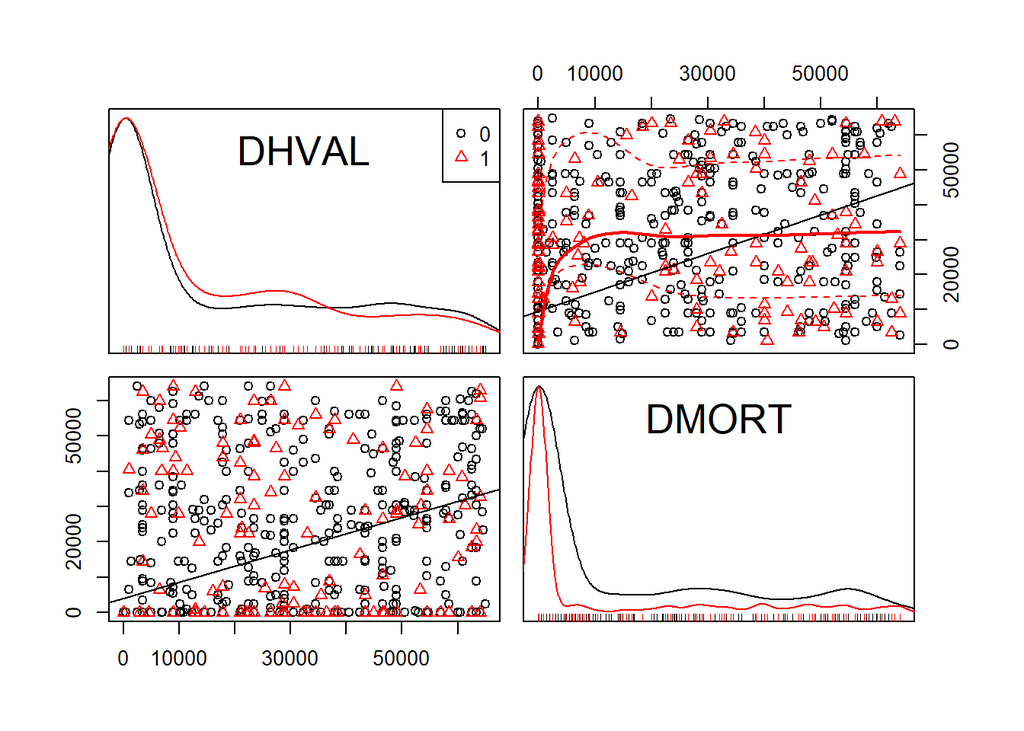

```r
scatterplot.matrix(~DHVAL+DMORT|BAD, data = df)
```

### 2.Feature Engineering

Based on the understanding of our variables and several train and error procedure, have done the below modification to the data.

1. Age:

The credit score data was collected somewhere around 1980’s. Assuming the minimum age of the credit card holder to be 21. I am assuming the date of the survey to be 1990.

Age <- 1990 - DOB ( formula = 90 - dob)

2. Net Family Income:

It is the sum of the income of the individual and the spouse, after negating the debts , interests and montly payments.

netFamIncome <- Applicant Income + Spouce Income -(outstandings)

3. Net Home Value:

Net Home Value is found by removing the mortage value of the home from the actual value of the home

Home Value <- Value of Home - Mortgage outstanding

4. Total Number of Dependants:

Both the number of children and number of other depandants are not having effect on the response on absence of other variables.

Total Dependants = No. of Kids + No. of other dependants

> Note After trying different ratio such as (income/expenditure) and (homeval/mortage) they are found to be insignificant, hence sticking to the absolute value of the variables.

```r
df$Age <- 90 - df$DOB
df$totalOut <- df$DOUTM+df$DOUTCC + df$DOUTL + df$DOUTHP
df$netPerIncome<- df$DAINC - df$totalOut
df$netFamIncome<- df$DAINC + df$SINC - df$totalOut
df$homeVal <- df$DHVAL - df$DMORT
df$totDep <- df$NKID + df$DEP
```

THe Final Table will have the following variables:

```r
names(df)
```

```
##  [1] "DOB"          "NKID"         "DEP"          "PHON"
##  [5] "SINC"         "AES"          "DAINC"        "RES"
##  [9] "DHVAL"        "DMORT"        "DOUTM"        "DOUTL"
## [13] "DOUTHP"       "DOUTCC"       "BAD"          "Age"
## [17] "totalOut"     "netPerIncome" "netFamIncome" "homeVal"
## [21] "totDep"
```

Difficulties and anomaly in the dataset

1. Home owners seems to be have more Bad credits

```r
library(dplyr)
aggregate(BAD ~ RES, data=df, FUN=sum)
```

```
##   RES BAD
## 1   F  30
## 2   N  31
## 3   O 164
## 4   P  60
## 5   U  38
```

2. According to the formula for home value, The negative value of homeVal means
   1. They have high mortgage on the home than its value
   2. The details of the home are not provided(0 also means no-response)
   3. they have not given both DHVAL and DMORT

Surprisingly there were no “00001” Zero value for any home or mortgage.

47 Home owners seems to have higher mortgate than the actual value of the home.

```r
df %>%
  filter(homeVal < 0) %>%
  filter(BAD == 1)
```

[output not shown]

```r
df %>%
  filter(RES == "O") %>%
  filter(DHVAL == 0)
```

[output not shown]

There are 587 people who have no ownership of home. of which, 14 people who are not owners, but have reported DHVAL and DMORT value.

Now let’s try to impute the value of the DHVAL and DMORT with the average of the non zero values of DHVAL and DMORT respectively.

```r
meanHomeValue <- mean(df$DHVAL[df$RES=="O"][df$DHVAL[df$RES=="O"] != 0])
meanMortValue <- mean(df$DMORT[df$RES=="O"][df$DMORT[df$RES=="O"] != 0])
```

Also imputing the age of the unknown individuals as 39 , the average age of all the people.

```r
df$Age[df$Age == -9] <- 39

for (i in 1:1225){
  if(df$RES == "O"){
    if(df$DHVAL == 0){
      df$DHVAL <- meanHomeValue
      df$DMORT<-  meanMortValue
      df$homeVal <- df$DHVAL - df$DMORT
    }
  }
}
```

```r
df$homeVal <- ifelse(df$homeVal < 0 , 0, df$homeVal)
```

##### Pie chart comparison for categorical variables

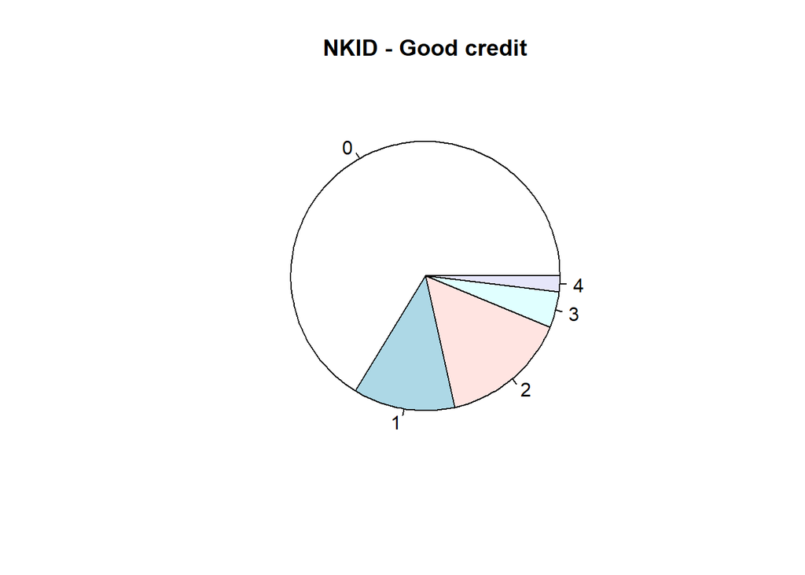

```r
df_temp <- table(df$BAD, df$NKID)
pie(df_temp[c(1,3,5,7,9)],c(0:5),main = "NKID - Good credit")
```

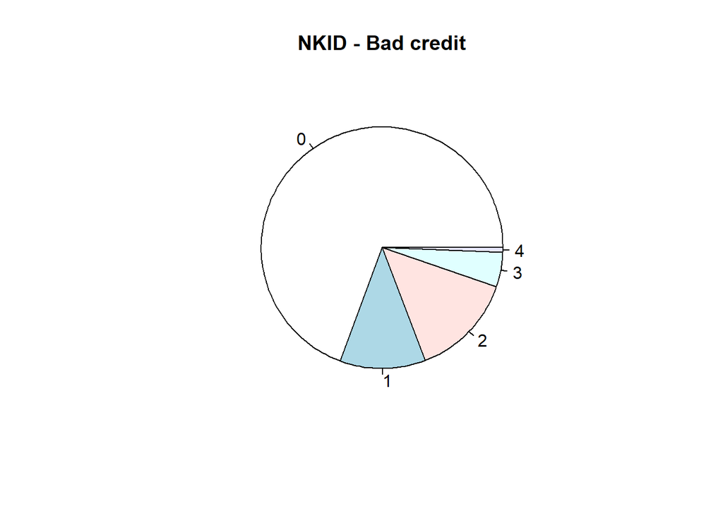

```r
pie(df_temp[c(2,4,6,8,10)],c(0:5), main = "NKID - Bad credit")
```

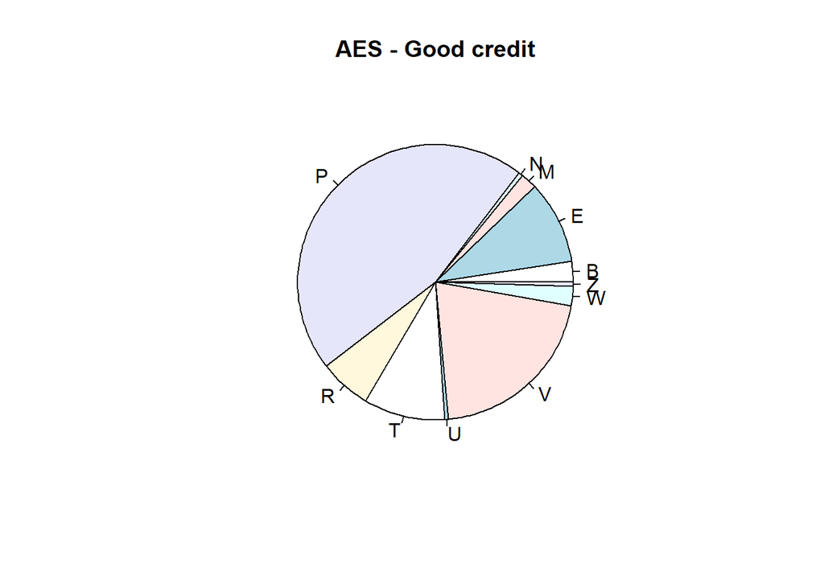

```r
df_temp <- table(df$BAD, df$AES)
pie(df_temp[c(1,3,5,7,9,11,13,15,17,19,21)],c('B','E','M','N','P','R','T','U','V' ,'W', 'Z'),main = "AES - Good credit")
```

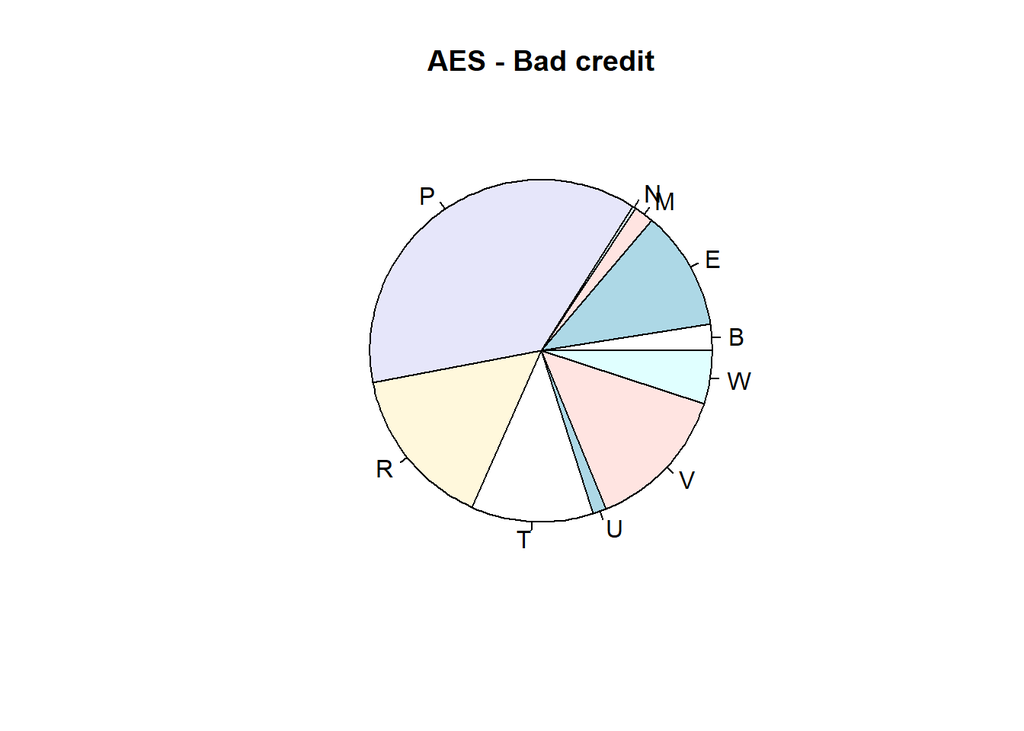

```r
pie(df_temp[c(2,4,6,8,10,12,14,16,18,20)],c('B','E','M','N','P','R','T','U','V' ,'W', 'Z'), main = "AES - Bad credit")
```

[figure not shown]

```r
df_temp <- table(df$BAD, df$RES)
pie(df_temp[c(1,3,5,7,9)],c('F','N','O' ,'P', 'U'),main = "AES - Good credit")
```

[figure not shown]

```r
pie(df_temp[c(2,4,6,8,10)],c('F','N','O' ,'P', 'U'), main = "AES - Bad credit")
```

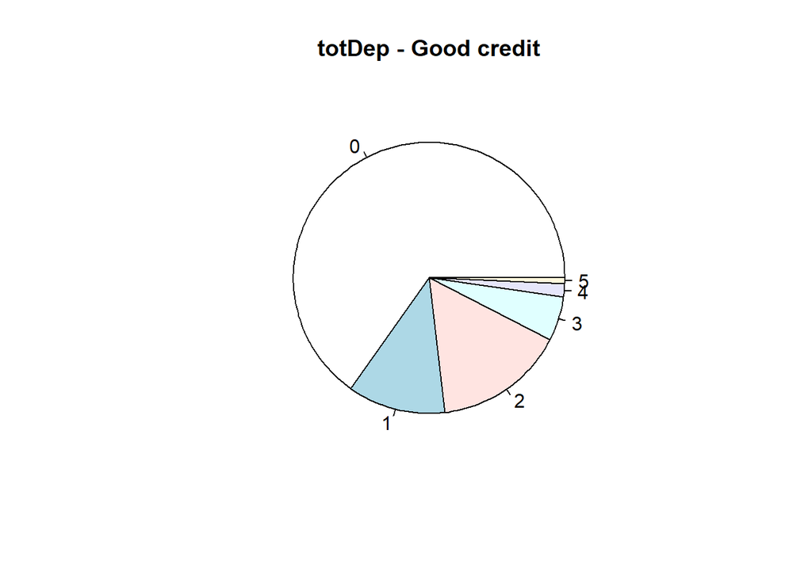

```r
df_temp <- table(df$BAD, df$totDep)
pie(df_temp[c(1,3,5,7,9,11)],c(0,1,2,3,4,5),main = "totDep - Good credit")
```

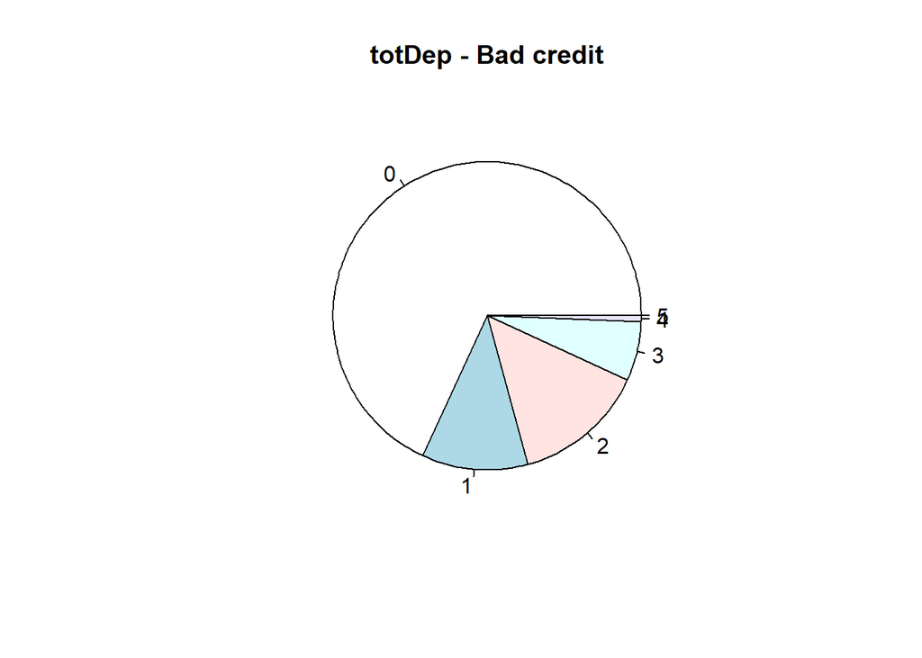

```r
pie(df_temp[c(2,4,6,8,10,12)],c(0,1,2,3,4,5), main = "totDep - Bad credit")
```

Some other interesting comparisions

26.28 % of the Owners have bad credits

24.8% of the phone holders have bad credits

The 25% Phone holders who are also owners( almost all the owners except 40 people) are having bad Credits

```r
aggregate(BAD ~ PHON , data=df, FUN = sum)
```

```
##   PHON BAD
## 1    0  38
## 2    1 285
```

```r
aggregate(BAD ~ RES , data=df, FUN=sum)
```

```
##   RES BAD
## 1   F  30
## 2   N  31
## 3   O 164
## 4   P  60
## 5   U  38
```

```r
aggregate(BAD ~ PHON + RES, data=df, FUN=sum)
```

```
##    PHON RES BAD
## 1     0   F  10
## 2     1   F  20
## 3     0   N  10
## 4     1   N  21
## 5     0   O  10
## 6     1   O 154
## 7     0   P   6
## 8     1   P  54
## 9     0   U   2
## 10    1   U  36
```

Replacing the rest of the negative values of the net Family income with 0’s.

```r
df$netFamIncome <- ifelse(df$netFamIncome < 0, 0 , df$netFamIncome)
```

Choosing the Variables for my final dataset.

1)Total Dependants

2)Age

3)Home Value

4)Residential Status

5)Applicant’s employment status

6)Phone

7)Net Family Income

8)Bad Credit

```r
#choosing Variables
dfFinal <- df[c(21,16,19,20,8,6,4,15)]
dfFinal <- data.frame(dfFinal)
#Adding Column names
colnames(dfFinal)<- c("totDep","Age","netFamIncome","homeVal","RES","AES","PHON","bad")
#converting the variables to categorical
dfFinal$totDep <- as.factor(dfFinal$totDep)
dfFinal$PHON <- as.factor(dfFinal$PHON)
dfFinal$bad <- as.factor(dfFinal$bad)
#AES and #Res are already factors
```

Writing the file for further analysis

```r
#Writring the file as csv for further analysis
write.csv(dfFinal,"dfFinal.csv",row.names = FALSE)
```